# Analysis of Hypothetical Estimands

Practical Worksheet

24 September 2024

| **Tobias Mütze<sup>1</sup>** tobias.muetze@novartis.com | **Simon Newsome<sup>1</sup>** simon.newsome@novartis.com |
| --- | --- |
| <sup>1</sup>Novartis Pharma AG, Basel, Switzerland |  |

# Preface

This worksheet will guide you through an analysis of the example randomized controlled trial in patients with type 2 diabetes. The analyses in this worksheet target a **hypothetical estimand**, i.e., we are interested in the comparison between the treatment group and the placebo group **in a setting where all patients would adhere to randomized treatment until the end of follow-up**.

This code follows the approach outlined in the paper “Hypothetical Estimands in Clinical Trials: A Unification of Causal Inference and Missing Data Methods” by Parra C.O. et al. (https://doi.org/10.1080/19466315.2022.2081599).

# 1 Set up

First, ensure that the following packages are installed and loaded, and also set the working directory to the folder containing the example datasets.

```r
rm(list = ls())

###Install and load required packages
if(!require(tidyverse)) {install.packages("tidyverse"); library(tidyverse)}
if(!require(here)) {install.packages("here"); library(here)}
if(!require(janitor)) {install.packages("janitor"); library(janitor)}
if(!require(knitr)) {install.packages("knitr"); library(knitr)}
if(!require(table1)) {install.packages("table1"); library(table1)}
if(!require(sandwich)) {install.packages("sandwich"); library(sandwich)}
if(!require(mice)) {install.packages("mice"); library(mice)}
if(!require(lmtest)) {install.packages("lmtest"); library(lmtest)}
```

```r
###Set working directory
setwd("~/GMDS/Material/Session 3/Practical")
```

# 2 Trial where all participants adhered to randomized treatment

In this section, we imagine that we ran a trial where all patients adhered to their randomized treatment.

## 2.1 Load Data

Load the dataset `DiabetesExampleData_wide_noICE.rds`, which contains the ideal trial in which no intercurrent events were observed. The dataset is contextually the same as those used previously in the Treatment Policy Estimands Practical, except that for the analyses in this worksheet we will primarily work with data in wide, rather than long, format.

```r
# Load the data
data_noICE <- read_rds(here("DiabetesExampleData_wide_noICE.rds"))
```

| Parameter name | Description |
| --- | --- |
| subjid | Unique subject identifier (1 - 400) |
| group | Randomized treatment assignment (trt=active treatment, ctl=control/placebo) |
| ontrt_x | Has patient adhered to assigned treatment at visit x? (1=yes, 0=no)* |
| hba1cBl | Value of HbA1c at baseline visit |
| hba1c_x | Value of HbA1c at visit x |
| hba1cChg_5 | Change in HbA1c from baseline to visit 5 (primary outcome) |

*Note that in the dataset loaded above `ontrt_x` is always equal to 1, because all patients adhered to randomized treatment until the end of follow-up. Later in this worksheet, we will load the dataset where some patients did not adhere to randomized treatment.

## 2.2 Review Data

Let us create a boxplot showing HbA1c values by visit and treatment group.

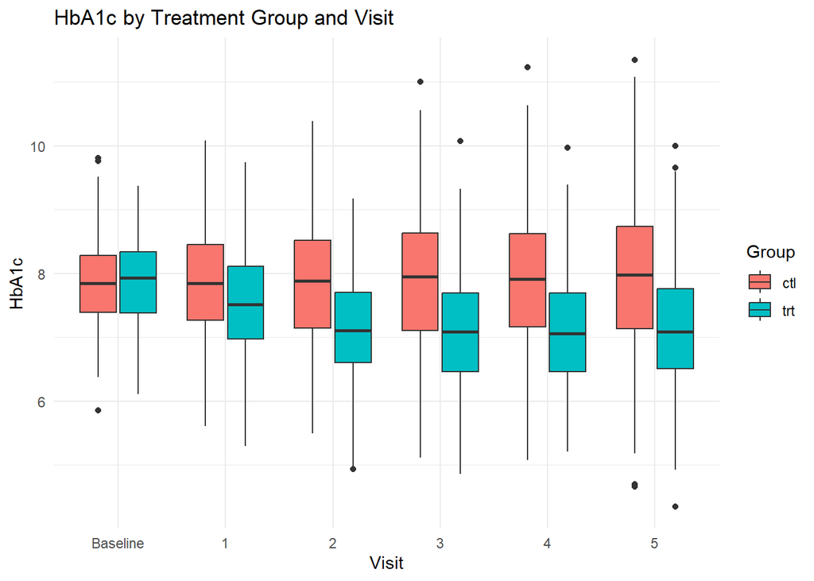

```r
# Create a boxplot showing HbA1c values by visit and treatment group
ggplot(data_noICE %>%
         pivot_longer(
           cols = c(hba1cBl, hba1c_1, hba1c_2, hba1c_3, hba1c_4, hba1c_5),
           names_to = "Visit",
           values_to = "hba1c") %>%
         mutate(Visit = factor(Visit, levels = c("hba1cBl", "hba1c_1", "hba1c_2", "hba1c_3", "hba1c_4", "hba1c_5"))),
       aes(x = Visit, y = hba1c, fill = group)) +
  geom_boxplot() +
  labs(title = "HbA1c by Treatment Group and Visit",
       x = "Visit",
       y = "HbA1c",
       fill = "Group") +
  scale_x_discrete(labels = c("Baseline", 1, 2, 3, 4, 5)) +
  theme_minimal()
```

**Question 1:** Which group has a lower median HbA1c at baseline?  
Control Treatment

**Question 2:** Which group has a lower median HbA1c at the end of follow-up?  
Control Treatment

## 2.3 Analysis of Data

As we have no patients experiencing the intercurrent event, we can perform our analysis just using ANCOVA. Our primary estimand is interested in the change in HbA1c from baseline to week 26 (visit 5).

```r
#Perform ANCOVA
results_noICE <- data_noICE %>%
                      lm(hba1cChg_5 ~ group + hba1cBl,data=.)
summary(results_noICE)
```

```
##
## Call:
## lm(formula = hba1cChg_5 ~ group + hba1cBl, data = .)
##
## Residuals:
##     Min      1Q  Median      3Q     Max
## -3.2518 -0.6455 -0.0299  0.7744  3.1562
##
## Coefficients:
##             Estimate Std. Error t value Pr(>|t|)
## (Intercept)  5.28553    0.63645   8.305 1.59e-15 ***
## grouptrt    -0.80323    0.10957  -7.331 1.29e-12 ***
## hba1cBl     -0.66254    0.08007  -8.275 1.97e-15 ***
## ---
## Signif. codes:  0 '***' 0.001 '**' 0.01 '*' 0.05 '.' 0.1 ' ' 1
##
## Residual standard error: 1.096 on 397 degrees of freedom
## Multiple R-squared:  0.2356, Adjusted R-squared:  0.2317
## F-statistic: 61.17 on 2 and 397 DF,  p-value: < 2.2e-16
```

**Question 3:** What is the estimated treatment effect (the difference in change from baseline in HbA1c for treatment versus control group)? (Give answer with 2 decimal places)

**Question 4:** What is its standard error? (Give answer with 2 decimal places)

# 3 Trial where some participants did not adhere to randomized treatment

Now we will move onto the more realistic example, where some patients did not adhere to their randomized treatment. We are interested in the **hypothetical estimand** as if all patients adhered to their randomized treatment.

## 3.1 Load Data

Load the dataset `DiabetesExampleData_wide.rds`, which contains trial data in the same format as above, but this time some patients did not adhere to randomized treatment, flagged in the dataset by `ontrt` equal to 0.

Note that in this dataset, we have observed values for HbA1c even after patients did not adhere to treatment. However, these values are not of interest to us for our analysis. Therefore, we will set to missing any values of HbA1c observed after the occurrence of the intercurrent event of treatment non-adherence.

```r
# Load the data
data_withICE <- read_rds(here("DiabetesExampleData_wide.rds"))

# Data post-ICE is not relevant for our analysis. Set any data post-ICE to missing.
data_withICE <- data_withICE %>%
  mutate(
    hba1c_1 = ifelse(ontrt_1 == 0, NA, hba1c_1),
    hba1c_2 = ifelse(ontrt_2 == 0, NA, hba1c_2),
    hba1c_3 = ifelse(ontrt_3 == 0, NA, hba1c_3),
    hba1c_4 = ifelse(ontrt_4 == 0, NA, hba1c_4),
    hba1c_5 = ifelse(ontrt_5 == 0, NA, hba1c_5),
    hba1cChg_5 = ifelse(ontrt_5 == 0, NA, hba1cChg_5)
  )
```

## 3.2 Review Data

Let us take a look at this dataset. In particular, the level of non-adherence to randomized treatment by group

```r
# Create summary table showing number and percentage of patients with missing data by visit and treatment group
table1(~ ontrt_1 + ontrt_2 + ontrt_3 + ontrt_4 + ontrt_5 | group, data_withICE)
```

|  | ctl (N=200) | trt (N=200) | Overall (N=400) |
| --- | --- | --- | --- |
| ontrt_1 |  |  |  |
| 0 | 8 (4.0%) | 5 (2.5%) | 13 (3.3%) |
| 1 | 192 (96.0%) | 195 (97.5%) | 387 (96.8%) |
| ontrt_2 |  |  |  |
| 0 | 18 (9.0%) | 12 (6.0%) | 30 (7.5%) |
| 1 | 182 (91.0%) | 188 (94.0%) | 370 (92.5%) |
| ontrt_3 |  |  |  |
| 0 | 31 (15.5%) | 20 (10.0%) | 51 (12.8%) |
| 1 | 169 (84.5%) | 180 (90.0%) | 349 (87.3%) |
| ontrt_4 |  |  |  |
| 0 | 43 (21.5%) | 27 (13.5%) | 70 (17.5%) |
| 1 | 157 (78.5%) | 173 (86.5%) | 330 (82.5%) |
| ontrt_5 |  |  |  |
| 0 | 50 (25.0%) | 29 (14.5%) | 79 (19.8%) |
| 1 | 150 (75.0%) | 171 (85.5%) | 321 (80.3%) |

**Question 5:** What percentage of trial participants in the active treatment group experienced the intercurrent event of treatment non-adherence? (Give answer with 1 decimal place)  
%

**Question 6:** What percentage of the trial participants in the control group experienced the intercurrent event of treatment non-adherence? (Give answer with 1 decimal place)  
%

## 3.3 Analysis of Data

### 3.3.1 Analysis of Patients without Intercurrent Event

Let us first perform the analysis dropping any patients who did not adhere to treatment, i.e., only using the observed outcome data in the patients who did adhere to their randomized treatment until the end of follow-up. This analysis will only provide an unbiased estimate of the treatment effect under the assumption that treatment non-adherence occurred completely at random in both treatment arms.

```r
#Perform ANCOVA
results_incorrect <- data_withICE %>%
                      lm(hba1cChg_5 ~ group + hba1cBl,data=.)
summary(results_incorrect)
```

```
##
## Call:
## lm(formula = hba1cChg_5 ~ group + hba1cBl, data = .)
##
## Residuals:
##     Min      1Q  Median      3Q     Max
## -3.1646 -0.7189 -0.0195  0.8072  3.1928
##
## Coefficients:
##             Estimate Std. Error t value Pr(>|t|)
## (Intercept)  5.99485    0.72999   8.212 5.51e-15 ***
## grouptrt    -0.73757    0.12147  -6.072 3.60e-09 ***
## hba1cBl     -0.76496    0.09408  -8.131 9.60e-15 ***
## ---
## Signif. codes:  0 '***' 0.001 '**' 0.01 '*' 0.05 '.' 0.1 ' ' 1
##
## Residual standard error: 1.081 on 318 degrees of freedom
##   (79 observations deleted due to missingness)
## Multiple R-squared:  0.2629, Adjusted R-squared:  0.2582
## F-statistic:  56.7 on 2 and 318 DF,  p-value: < 2.2e-16
```

**Question 7:** What is the estimated treatment effect (the difference in change from baseline in HbA1c for treatment versus control group)? (Give answer with 2 decimal places)

**Question 8:** What is its standard error? (Give answer with 2 decimal places)

### 3.3.2 Analysis using Multiple imputation

Now, let us move onto more principled analyses, starting with a multiple imputation approach. Here, for the patients who experience the intercurrent event of treatment non-adherence, we aim to impute what their values of HbA1c would have been if they had not experienced the intercurrent event by modelling the hypothetical future trajectory based on their past trajectory and the trajectories of similar patients.

As soon as a patient experiences the intercurrent event of treatment non-adherence, all future values of HbA1c will be missing. Therefore, we have a **monotone** missingness pattern, i.e., if a patient discontinues treatment at visit 1, then HbA1c will be missing from visit 1 to visit 5, whereas if a patient discontinues treatment at visit 4, then HbA1c will only be missing for visits 4 and 5.

The code below will perform a **sequential imputation** starting by imputing HbA1c at visit 1, sequentially through the visits, finally imputing HbA1c at visit 5. Each imputation is performed using Bayesian linear regression `method="norm"` including treatment and all previous values of HbA1c.

We then fit our ANCOVA model to each imputed dataset, and finally pool the results of each imputation using Rubin’s rules to obtain a point estimate and its standard error.

```r
# Keep only data that will be used in the MI process
# Treatment group, HbA1c at baseline and follow-up visits 1-4, and
#  Change in HbA1C at visit 5 (outcome)
missing.data <- data_withICE[,c(2,8:12,14)]

set.seed(2545)

# Impute sequentially following monotone missingness
  MI.data <-
    mice(missing.data,
         m=100,
         method="norm",
         printFlag = F,
         visitSequence = "monotone",
         maxit = 1)

# Fit ANCOVA model to each multiply imputed dataset
  fit <- with(MI.data, lm(hba1cChg_5 ~ group + hba1cBl))

#Pool results using Rubin's rules
  results_MI <- pool(fit)
  summary(results_MI)
```

```
##          term   estimate  std.error statistic       df      p.value
## 1 (Intercept)  5.2961129 0.73074146  7.247588 261.8575 4.762653e-12
## 2    grouptrt -0.8316542 0.12376240 -6.719765 277.6998 1.029454e-10
## 3     hba1cBl -0.6576815 0.09386676 -7.006543 243.0176 2.388341e-11
```

*Note: Ensure to use seed(2545) to obtain same results*  
**Question 9:** What is the estimated treatment effect (the difference in change from baseline in HbA1c for treatment versus control group? (Give answer with 2 decimal places)

**Question 10:** What is its standard error? (Give answer with 2 decimal places)

### 3.3.3 Analysis using Inverse Probability Weighting (IPW)

Another way to perform this analysis is to use inverse probability weighting. In this approach, we only use the outcome data for the patients who did not experience the intercurrent event, but we up-weight these patients in such a way that they also represent what we estimate would have been observed in similar patients who did experience the intercurrent event.

The weights are given by the **inverse of the propensity score**, which is the propensity for patients to experience the intercurrent event at each visit. We start by calculating the weights to account for patients who experienced the intercurrent event at visit 1.

```r
# Propensity score for Treatment Adherence at Visit 1
  PS <- glm(ontrt_1 ~ group*hba1cBl,
              data = data_withICE,
              family = "binomial")

# Add weights for Treatment Adherence at Visit 1
# For patients who did not experience the intercurrent event, the weights
#   are given by 1/(probability of experiencing intercurrent event)
#  PS$fitted.values contains the probability that ontrt_1==1 for each patient
# Drop patients who had the intercurrent event at visit 1
IPW.data <- data_withICE %>%
              mutate(weights= 1/PS$fitted.values) %>%
              filter(ontrt_1==1)

# Check summary statistics of the weights for visit 1
table1(~ weights | group, IPW.data,
       render.continuous=c(.="Mean (SD)", .="Median [Min, Max]",.="Sum"))
```

|  | ctl (N=192) | trt (N=195) | Overall (N=387) |
| --- | --- | --- | --- |
| weights |  |  |  |
| Mean (SD) | 1.04 (0.0615) | 1.03 (0.0284) | 1.03 (0.0484) |
| Median [Min, Max] | 1.02 [1.00, 1.51] | 1.02 [1.00, 1.16] | 1.02 [1.00, 1.51] |
| Sum | 200 | 200 | 400 |

**Question 11:** What is the mean weight in the control group? (Give answer with 2 decimal places)

**Question 12:** What is the sum of the weights in the treatment group? (Give answer as an integer)

Our original sample size was 400 patients (200 in each arm). At visit 1, 8 patients had experienced the intercurrent event in the control arm, and 5 patients in the treatment arm. This reduced our sample size to 192 and 195 respectively, but through up-weighting patients who were similar to those who experienced the intercurrent event, we have maintained an effective sample size of 200 per arm.

Next we continue this process sequentially from visit 2 up to the end of follow-up.

```r
# Loop for visits 2-5:
  for (i in 2:5) {

    # Fit the GLM
    # As well as hba1cBl. We also include the previous value of hba1c into each model
    PS <- glm(paste0("ontrt_", i, " ~ group*hba1cBl+group*hba1c_", i-1),
              data = IPW.data, family = "binomial")

    # Update weights: Weight at visit 2 = (1/PS_1) * (1/PS_2), etc
    # Drop patients who had intercurrent event at each visit sequentially
    #  At the end, we will only have patients who did not experience the intercurrent event
    IPW.data <- IPW.data  %>%
                    mutate(weights = weights/PS$fitted.values) %>%
                    filter(get(paste0("ontrt_", i)) == 1)
  }

# Check summary statistics of the final weights
table1(~ weights | group, IPW.data,
       render.continuous=c(.="Mean (SD)", .="Median [Min, Max]",.="Sum"))
```

|  | ctl (N=150) | trt (N=171) | Overall (N=321) |
| --- | --- | --- | --- |
| weights |  |  |  |
| Mean (SD) | 1.36 (1.64) | 1.18 (0.243) | 1.26 (1.14) |
| Median [Min, Max] | 1.11 [1.00, 20.9] | 1.11 [1.01, 3.41] | 1.11 [1.00, 20.9] |
| Sum | 203 | 202 | 405 |

**Question 13:** What is the largest weight? (Give answer with 1 decimal places)

**Question 14:** What is the sum of the weights in the treatment group? (Give answer as an integer)

It is always a good idea to check the weights, because extreme weights can highlight potential violations of the positivity and/or modelling assumptions.

In the example above, the largest weight is almost 21. This means that the data of this one patient is now being used to represent twenty other similar patients who did not adhere to the randomized treatment. We could consider this as suggesting that patients with these characteristics only have a 1/21 = ~5% probability of adhering to their randomized treatment. This is perhaps not so extreme, and suggests that the positivity assumption holds in this case. However, it is not uncommon to see examples with weights >100, meaning this patient had less than 1% probability of not experiencing the intercurrent event. Although this would still strictly meet the positivity assumption that the probability is >0 and <1, the variance estimation will start to increase significantly as weights become more extreme.

The sum of the weights should equal the original sample size in each treatment arm. Here we see the sum of the weights in each arm is not quite equal to 200, but it is close. There is no strict limit on what can be considered ‘close enough’, but if the sum of the weights differs significantly from the original sample size it can suggest issues with the modelling of the propensity score.

Finally, we can check the results by fitting a weighted linear regression. The variance is estimated using a “robust” (Huber-White) sandwich estimator to account for the weighting.

```r
  results_IPW <- IPW.data %>%
    lm(hba1cChg_5 ~ group + hba1cBl,data=.,weights=weights)

  coeftest(results_IPW, vcov = vcovHC)
```

```
##
## t test of coefficients:
##
##              Estimate Std. Error t value  Pr(>|t|)
## (Intercept)  5.201939   0.625226  8.3201 2.619e-15 ***
## grouptrt    -0.787932   0.126312 -6.2380 1.412e-09 ***
## hba1cBl     -0.650241   0.078175 -8.3178 2.661e-15 ***
## ---
## Signif. codes:  0 '***' 0.001 '**' 0.01 '*' 0.05 '.' 0.1 ' ' 1
```

**Question 15:** What is the estimated treatment effect (the difference in change from baseline in HbA1c for treatment versus control group)? (Give answer with 2 decimal places)

**Question 16:** What is its standard error? (Give answer with 2 decimal places)

# 4 Further work

Note that the robust variance estimation used above assumes that the propensity score is known rather than estimated. This leads to a conservative **overestimated variance**. Unbiased variance estimates can instead be obtained via a bootstrap procedure.

If you have time, write a bootstrap procedure to obtain an unbiased estimate of the variance for the IPW approach.

```r
IPW <- function(data) {
    # Visit 1
    PS <- glm(ontrt_1 ~ group*hba1cBl,
              data = data,
              family = "binomial")
    IPW.data <- data %>%
      mutate(weights= 1/PS$fitted.values) %>%
      filter(ontrt_1==1)

    # Visits 2 to 5
    for (i in 2:5) {
        PS <- glm(paste0("ontrt_", i, " ~ group*hba1cBl+group*hba1c_", i-1), data = IPW.data, family = "binomial")
      IPW.data <- IPW.data  %>%
        mutate(weights = weights/PS$fitted.values) %>%
        filter(get(paste0("ontrt_", i)) == 1)
    }

    results_IPW <- IPW.data %>%
      lm(hba1cChg_5 ~ group + hba1cBl,data=.,weights=weights)
    return(results_IPW$coefficients[2])
}

# Bootstrap
  #Number of bootstrap resamples
  n_boot <- 10000

  # Store treatment effects from each bootstrap sample
  treatment_effects <- numeric(n_boot)

  set.seed(6253)
  # Run bootstrap
  for (i in 1:n_boot) {

    success <- FALSE
    while (!success) {

      # Resample the data with replacement
      boot_sample <- data_withICE %>% slice_sample(n=400,replace=TRUE)

      result <- tryCatch({
        treatment_effects[i] <- IPW(boot_sample)
        success <- TRUE  # Mark success if no error/warning
      }, warning = function(w) {}, error = function(e) {})
      }
    }

  # Calculate the bootstrap standard error
  bootstrap_se <- sd(treatment_effects)

  # Print the bootstrap standard error
  bootstrap_se
```